# Comparing the Effects of Shading and Long-Term Warming on Sphagnum Water Content in a Northern Peatland

Elisa Herter

```r
knitr::opts_chunk$set(echo = TRUE, message = FALSE, warning = FALSE)

library(tidyverse)
library(knitr)
library(dplyr)
library(kableExtra)
```

```r
library(ggplot2)
library(ggthemes)

theme_update(
  axis.title = element_text(size = 14),
  axis.text  = element_text(size = 12),
  title      = element_text(size = 15)
)

opts_knit$set(eval.after = 'fig.cap')

calcSE <- function(x) {
  x <- x[!is.na(x)]
  sd(x) / sqrt(length(x))
}
```

```r
shade_map <- c("0" = 0, "1" = 30, "2" = 60, "3" = 80, "4" = 90)

# Load shading harvest data
# replace missing values
#covert to percentage, convery units to 0-1 proportions
harvest <- read_csv("Data/Sphagnum_ shade_harvest.csv") %>%
  mutate(across(where(is.numeric), ~ ifelse(. == -9999, NA, .)), #replace missing values
         Shade_pct = shade_map[as.character(Shade)],
         WC_prop   = Water_content / (1 + Water_content)) #convert

shade_length <- read_csv("Data/Sphagnum_shade_length.csv") %>%
  mutate(across(where(is.numeric), ~ ifelse(. == -9999, NA, .)),
         Shade_pct = shade_map[as.character(Shade)])

shade_photo <- read_csv("Data/Sphagnum_shade_photosynthesis.csv")

# Load phytobiome warming dataset
cn_water <- read_csv("Data/Sphagnum_CN_Water_content_2017_2021.csv") %>%
  mutate(across(where(is.numeric), ~ ifelse(. == -9999, NA, .)),
         CO2_treatment = factor(CO2_treatment, levels = c("Ambient", "Elevated")),
         Year = as.factor(Year)) %>%
  filter(!is.na(Water_content))

incubations <- read_csv("Data/Sphagnum_incubations_2017_2021.csv") %>%
  mutate(across(where(is.numeric), ~ ifelse(. == -9999, NA, .)))

# Regressions
lm_shade <- lm(WC_prop ~ Shade_pct, data = harvest) #FOR H1
s_shade  <- summary(lm_shade) #FOR H1

#FOR H2
lm_warm  <- lm(Water_content ~ Temperature_treatment, data = cn_water)
s_warm   <- summary(lm_warm)  #pvalue and R2

#FOR H3
shade_delta   <- coef(lm_shade)[2] * 90
warming_delta <- coef(lm_warm)[2]  * 9

#FOR H4
lm_two  <- lm(Water_content ~ Temperature_treatment + CO2_treatment, data = cn_water)
aov_two <- anova(lm_two) #for pvalue
```

## I. Literature Review

Anthropogenic greenhouse gas emissions have dramatically altered the global carbon cycle, with atmospheric CO₂ rising by over 50% since pre-industrial times and continuing to accelerate (NOAA, 2024). Northern peatlands store roughly one-third of global terrestrial soil carbon, more per unit area than any other ecosystem and this storage depends almost entirely on Sphagnum moss keeping the peat saturated and anaerobic (Gorham, 1991; Yu et al., 2010). Sphagnum can hold up to 20 times its own dry mass in water through specialized hyaline cells, and when it dries out, decomposition accelerates and centuries of stored carbon are released back to the atmosphere (Rydin & Jeglum, 2013; Dise, 2009). As climate change drives rising temperatures and elevated atmospheric CO₂, Sphagnum dominated peatlands are considered near a tipping point at which they could flip from carbon sinks to carbon sources (Schultheis et al., 2010). Understanding what drives Sphagnum water loss is therefore central to projecting future peatland carbon storage and the climate feedbacks that follow.

Two mechanisms have been proposed to explain Sphagnum desiccation under climate change: direct warming, which accelerates evapotranspiration and draws water out of the moss (Keane et al., 2025), and canopy shading by expanding shrubs, which reduces the solar radiation that drives evaporation at the moss surface (Chong et al., 2012; Norby et al., 2023). Warming has been shown to reduce Sphagnum water content directly through increased evaporative demand, and Keane et al. (2025) demonstrated that recovery from drought is species-specific and often incomplete, suggesting that even brief desiccation events can have lasting consequences for moss water status. Shading has a more complicated relationship with water content: while reduced light limits surface evaporation, it also reduces photosynthesis and the capitulum activity that draws water upward through the plant via capillary action (Murray et al., 1993; Goetz & Price, 2015). Bengtsson et al. (2020) showed that species-specific differences in water economy mean that shading effects can vary widely even between closely related Sphagnum taxa, making generalizations difficult. Elevated CO₂ adds further complexity by stimulating vascular plant growth and potentially intensifying canopy shading, though its direct effects on Sphagnum water status are poorly understood since Sphagnum lacks stomata (Newman et al., 2018). Van de Koot et al. (2024) recently demonstrated that water-holding capacity in Sphagnum depends on both plant and colony structure, meaning that changes in growth form under altered light or temperature environments can modify water retention independent of surface evaporation. Because warming, shading, and CO₂ co-occur in most experimental systems, isolating which driver matters most has remained a fundamental challenge.

A growing body of experimental work has sought to disentangle these drivers using manipulative field experiments. Norby et al. (2023) showed that shading contributes to Sphagnum decline in response to warming at the SPRUCE experiment, but noted that the warming effect persisted even after accounting for shade, suggesting temperature operates through additional pathways. Chong et al. (2012) found that increasing shrub cover in a Canadian bog reduced moss surface evaporation and maintained higher water content, supporting the idea that shade from vascular plant encroachment could buffer desiccation. However, these studies addressed shading and warming as correlated variables within the same treatment, making it impossible to quantify their independent contributions. What has been lacking is a direct, controlled comparison of the magnitude of each driver’s effect on Sphagnum water content using experiments where temperature and light are manipulated independently at the same site and converted to a common unit for comparison.

The SPRUCE (Spruce and Peatland Responses Under Changing Environments) experiment at the Marcell Experimental Forest in northern Minnesota provides a uniquely powerful platform for addressing this gap. SPRUCE is a large-scale whole-ecosystem warming and elevated CO₂ experiment managed by Oak Ridge National Laboratory, with open-top enclosures spanning five temperature treatments (+0 to +9°C above ambient) crossed with ambient or elevated CO₂ (~+500 ppm) (Hanson et al., 2017). The site has been continuously monitored since treatment initiation in 2015, generating one of the most comprehensive multi-year datasets on peatland ecosystem response to climate manipulation available. A companion 2021 shading experiment at the same S1 bog site applied five shade cloth densities (0–90%) to replicated Sphagnum plots outside the warming enclosures with no temperature manipulation, isolating the effect of light reduction on water content independently of warming (Norby et al., 2023). The phytobiome dataset (Petro et al., 2023) records Sphagnum tissue water content and microbial activity from inside the warming enclosures from 2017–2021. Together, these two independently published datasets make it possible for the first time to directly compare the magnitude of shading and warming effects on Sphagnum water content using data from the same ecosystem.

This analysis integrates the two SPRUCE datasets to ask whether increasing shade raises Sphagnum water content by as much as long-term warming lowers it, and what this comparison reveals about whether light or temperature is the more important driver of peatland water storage. By converting both datasets to the same water content unit and plotting their response curves on a shared scale, this project produces a direct visual and statistical comparison that has not previously been made using these newly published datasets. If shading matters as much as warming, it would suggest that managing shrub encroachment could meaningfully slow peatland desiccation even as temperatures rise — a finding with clear conservation implications (Chong et al., 2012; Newman et al., 2018). If warming is the stronger driver, it would reinforce the case that only direct emissions reductions can prevent peatland carbon loss at the scale projected under future climate scenarios.

I predict that: (H1) increasing shade will increase Sphagnum water content in the shading experiment, because reduced solar radiation should lower evapotranspiration at the moss surface (Chong et al., 2012; Bengtsson et al., 2020); (H2) warming will decrease Sphagnum water content in the phytobiome dataset, as elevated temperatures drive greater evaporative water loss (Norby et al., 2023; Keane et al., 2025); (H3) the magnitude of water content change across the warming gradient will be greater than across the shading gradient, indicating that temperature drives desiccation through pathways beyond canopy shading alone; and (H4) elevated CO₂ will have a smaller independent effect on water content than temperature, since Sphagnum water relations depend primarily on physical evaporation and capillary structure rather than stomatal gas exchange (Newman et al., 2018; Goetz & Price, 2015).

## II. Methods

Datasets originate from the S1 bog at the Marcell Experimental Forest in northern Minnesota, the site of the SPRUCE (Spruce and Peatland Responses Under Changing Environments) experiment managed by Oak Ridge National Laboratory. The experiment manipulates temperature (+0 to +9°C in five levels) and CO₂ (ambient or ~+500 ppm elevated) inside large open-top enclosures, allowing researchers to study peatland ecosystem responses to the range of conditions projected under future climate scenarios (Hanson et al., 2017).

To enable cross-dataset comparison, water content in the shading dataset (g water / g dry mass) was converted to a 0–1 proportion using: WC<sub>prop</sub> = WC<sub>raw</sub> / (1 + WC<sub>raw</sub>). Shade treatment codes (0–4) were mapped to percent shade values (0, 30, 60, 80, 90%). Missing values coded as −9999 were replaced with NA throughout. Linear regression was used to assess each driver separately (H1, H2), slope magnitudes were compared across the full treatment range to assess relative driver strength (H3), and a two-way linear model with temperature and CO₂ as predictors was used to assess independent CO₂ effects (H4).

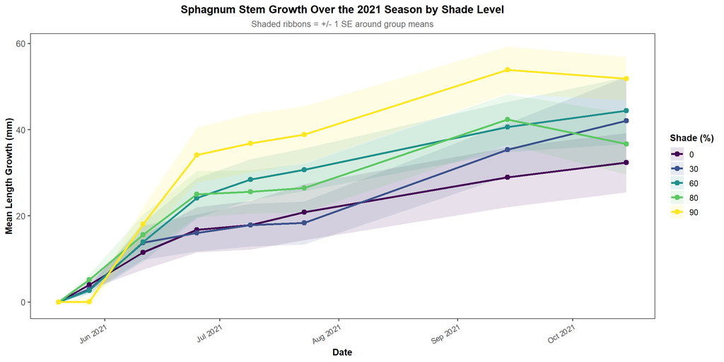

```r
shade_length %>%
  filter(!is.na(Length_growth)) %>%
  group_by(Shade_pct, Date) %>% #group by levels
  summarise(mean_growth = mean(Length_growth, na.rm = TRUE), #mean growth per group
            se_growth   = calcSE(Length_growth), .groups = "drop") %>%
  ggplot(aes(x = as.Date(Date), y = mean_growth, color = factor(Shade_pct))) +
  geom_ribbon(aes(ymin = mean_growth - se_growth, #below and above mean
                  ymax = mean_growth + se_growth,
                  fill = factor(Shade_pct)),
              alpha = 0.12, color = NA) +
  geom_line(linewidth = 1.1) +
  geom_point(size = 2.5) +       #connect points
  scale_color_viridis_d(name = "Shade (%)", option = "D") +
  scale_fill_viridis_d(name  = "Shade (%)", option = "D") +
  scale_x_date(date_breaks = "1 month", date_labels = "%b %Y") +
  labs(title    = "Sphagnum Stem Growth Over the 2021 Season by Shade Level", #;abels
       subtitle = "Shaded ribbons = +/- 1 SE around group means",
       x        = "Date",
       y        = "Mean Length Growth (mm)") +
  theme_few() + #minimal theme
  theme(
    plot.title      = element_text(hjust = 0.5, face = "bold", size = 13),
    plot.subtitle   = element_text(hjust = 0.5, size = 10,     color = "grey40"),
    axis.title      = element_text(face = "bold", size = 11,   hjust = 0.5),
    axis.text.x     = element_text(size = 9, angle = 30,       hjust = 1),
    axis.text.y     = element_text(size = 10),
    legend.title    = element_text(face = "bold", size = 11),
    legend.position = "right"
  )
```

Sphagnum stem length growth increased across the 2021 growing season under all shade levels. Heavily shaded plots (90%) showed the greatest total growth by October, while unshaded plots (0%) showed the least, suggesting that reduced light competition or lower evaporative stress under high shade may promote stem elongation even if water content differences were not statistically significant.

[figure not shown]

```r
# Preliminary: water content by year and temperature treatment

cn_water %>%
  group_by(Year, Temperature_treatment) %>% #group by year and temp
  summarise(mean_WC = mean(Water_content, na.rm = TRUE), #mean water content
            se_WC   = calcSE(Water_content), .groups = "drop") %>% #standard Error

  ggplot(aes(x = Temperature_treatment, y = mean_WC, color = Year)) +
  geom_line(linewidth = 1.1) +
  geom_point(size = 3) +
  geom_errorbar(aes(ymin = mean_WC - se_WC, ymax = mean_WC + se_WC),  # add error bar
                width = 0.2, linewidth = 0.5) +
  scale_color_manual(values = c("2019" = "blue",
                                "2021" = "red"),
                     name = "Year") +
  scale_x_continuous(breaks = c(-2, 0, 2.25, 4.5, 6.75, 9),
                     labels = c("-2C", "0C", "+2.25C",
                                "+4.5C", "+6.75C", "+9C")) +
  scale_y_continuous(limits = c(0.5, 1.0), breaks = seq(0.5, 1.0, 0.1)) +
  labs(title = "Warming Reduces Sphagnum Water Content Consistently Across Years",
       subtitle = "Each point = mean +/- 1 SE; data collected in 2019 and 2021 only",
       x = "Temperature Treatment (C above ambient)",
       y = "Mean Water Content (proportion)") +
  theme_few() +
  theme( # alignments
    plot.title      = element_text(hjust = 0.5, face = "bold", size = 13),
    plot.subtitle   = element_text(hjust = 0.5, size = 10, color = "grey40"),
    axis.title      = element_text(face = "bold", size = 11),
    axis.text.x     = element_text(size = 9, angle = 30, hjust = 1),
    legend.title    = element_text(face = "bold", size = 11),
    legend.position = "right"
  )
```

## III. Results

**H1 Shade increases Sphagnum water content:** A linear regression of Sphagnum water content (proportion) against shade level showed a positive but non-significant relationship (slope = 0.000206 per % shade, *p* = 0.1891, R² = 0.031), providing only weak and inconclusive support for H1. The small sample size and high within-treatment variability in this single-season experiment likely limited statistical power.

```r
a <- harvest %>%
  group_by(Shade_pct) %>%
  summarise(`Mean WC (proportion)` = round(mean(WC_prop, na.rm = TRUE), 3), #mean
            `SE`                   = round(calcSE(WC_prop), 4))  %>% #standard error
  rename(`Shade (%)` = Shade_pct)

knitr::kable(a,        #table format
  table.attr = "style='width:35%;'") %>%
  kable_styling(full_width = FALSE, position = "center")
```

| Shade (%) | Mean WC (proportion) | SE |
| --- | --- | --- |
| 0 | 0.893 | 0.0104 |
| 30 | 0.883 | 0.0149 |
| 60 | 0.900 | 0.0119 |
| 80 | 0.898 | 0.0129 |
| 90 | 0.910 | 0.0061 |

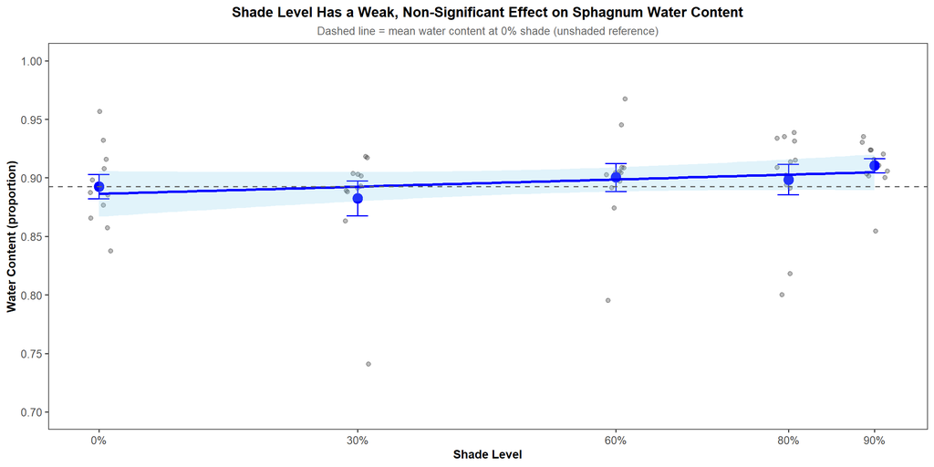

FIGURE 1: *Sphagnum* water content (proportion) across five shade levels in the 2021 SPRUCE shading experiment. Large points show group means ± 1 SE; small grey points show individual observations. The blue regression line with 95% CI is shown.

```r
cap1 <- "FIGURE 1: *Sphagnum* water content (proportion) across five shade levels in the 2021 SPRUCE shading experiment. Large points show group means ± 1 SE; small grey points show individual observations. The blue regression line with 95% CI is shown."

harvest %>%
  ggplot(aes(x = Shade_pct, y = WC_prop)) +
  geom_jitter(width = 1.5, alpha = 0.3, color = "grey10", size = 1.8) + #just jitter to avoid overplotting
  stat_summary(fun = mean, geom = "point", size = 4, color = "blue") + #group means
  stat_summary(fun.data = mean_se, geom = "errorbar", width = 2.5, color = "blue") + #standard error
  geom_smooth(method = "lm", color = "blue", fill = "skyblue", alpha = 0.25) + #linear regression with 95 percent conf interval
  geom_hline(yintercept = mean(harvest$WC_prop[harvest$Shade_pct == 0], na.rm = TRUE),
             lty = "dashed", color = "grey40", linewidth = 0.7) +
  scale_x_continuous(breaks = c(0, 30, 60, 80, 90), #xaxis values
                     labels = paste0(c(0, 30, 60, 80, 90), "%")) +
  scale_y_continuous(limits = c(0.7, 1.0), breaks = seq(0.7, 1.0, 0.05)) +
  labs(title = "Shade Level Has a Weak, Non-Significant Effect on Sphagnum Water Content",
       subtitle = "Dashed line = mean water content at 0% shade (unshaded reference)",
       x = "Shade Level",
       y = "Water Content (proportion)") +
  theme_few() +
  theme( #axis label formating
    plot.title    = element_text(hjust = 0.5, face = "bold", size = 13),
    plot.subtitle = element_text(hjust = 0.5, size = 10, color = "grey40"),
    plot.caption  = element_text(hjust = 0.5, size = 9,  color = "grey50"),
    axis.title    = element_text(face = "bold", size = 11),
    axis.text     = element_text(size = 10)
  )
```

**H2 Warming decreases Sphagnum water content:** A linear regression of water content against temperature treatment showed a significant negative relationship (slope = -0.0268 per °C, *p* < 0.0001, R² = 0.281), supporting H2. Water content declined substantially across the +0 to +9°C warming gradient.

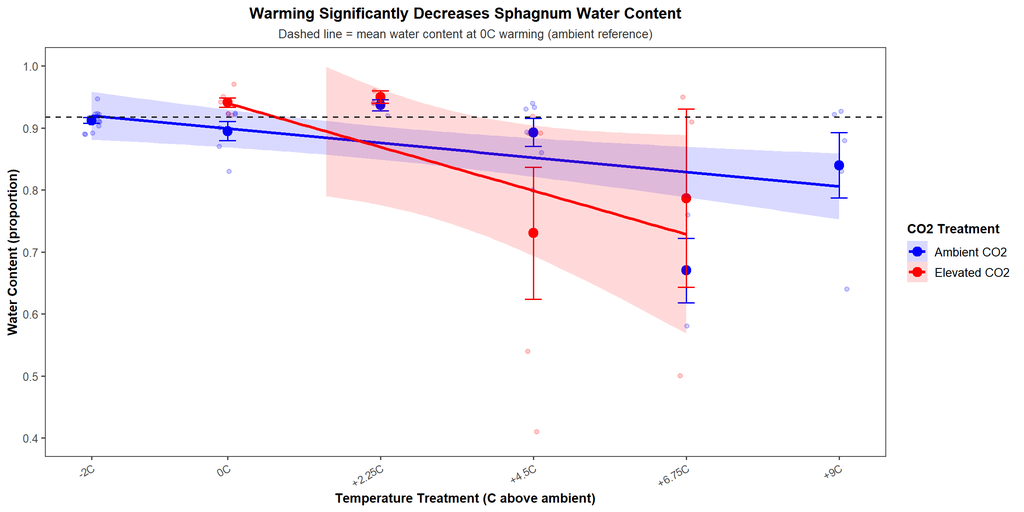

```r
cap2 <- "FIGURE 2: *Sphagnum* water content (proportion) across five temperature treatments in the SPRUCE phytobiome experiment (2019–2021), colored by CO₂ treatment. Large points show group means ± 1 SE. Lines show fitted linear regressions within each CO₂ treatment. The dashed line marks the mean water content at 0°C warming."

cn_water %>%
  ggplot(aes(x = Temperature_treatment, y = Water_content,
             color = CO2_treatment, fill = CO2_treatment)) +
  geom_jitter(width = 0.12, alpha = 0.2, size = 1.5) +
  stat_summary(fun = mean, geom = "point", size = 3.5) +
  stat_summary(fun.data = mean_se, geom = "errorbar", width = 0.25) +
  geom_smooth(method = "lm", alpha = 0.15) +
  geom_hline(yintercept = mean(cn_water$Water_content[cn_water$Temperature_treatment == 0],
                               na.rm = TRUE),
             lty = "dashed", color = "grey10", linewidth = 0.7) +
  scale_color_manual(values = c("Ambient" = "blue", "Elevated" = "red"),
                     name = "CO2 Treatment",
                     labels = c("Ambient CO2", "Elevated CO2")) +
  scale_fill_manual(values  = c("Ambient" = "blue", "Elevated" = "red"),
                    name = "CO2 Treatment",
                    labels = c("Ambient CO2", "Elevated CO2")) +
  scale_x_continuous(breaks = c(-2, 0, 2.25, 4.5, 6.75, 9),
                     labels = c("-2C", "0C", "+2.25C",
                                "+4.5C", "+6.75C", "+9C")) +
  scale_y_continuous(limits = c(0.4, 1.0), breaks = seq(0.4, 1.0, 0.1)) +
  labs(title = "Warming Significantly Decreases Sphagnum Water Content",
       subtitle = "Dashed line = mean water content at 0C warming (ambient reference)",
       x = "Temperature Treatment (C above ambient)",
       y = "Water Content (proportion)") +
  theme_few() +
  theme(
    legend.position  = "right",
    legend.title     = element_text(face = "bold", size = 11),
    legend.text      = element_text(size = 10),
    plot.title       = element_text(hjust = 0.5, face = "bold", size = 13),
    plot.subtitle    = element_text(hjust = 0.5, size = 10, color = "grey20"),
    plot.caption     = element_text(hjust = 0.5, size = 9, color = "grey30"),
    axis.title       = element_text(face = "bold", size = 11),
    axis.text.x      = element_text(size = 9, angle = 30, hjust = 1)
  )
```

**H3 Warming is a stronger driver than shading:** Multiplying each regression slope by its full treatment range, the total predicted change in water content was 0.019 proportion units across 0–90% shade, compared to 0.241 proportion units across 0–9°C warming, supporting H3. Figure 3 overlays both response curves on a shared scaled axis for direct comparison.

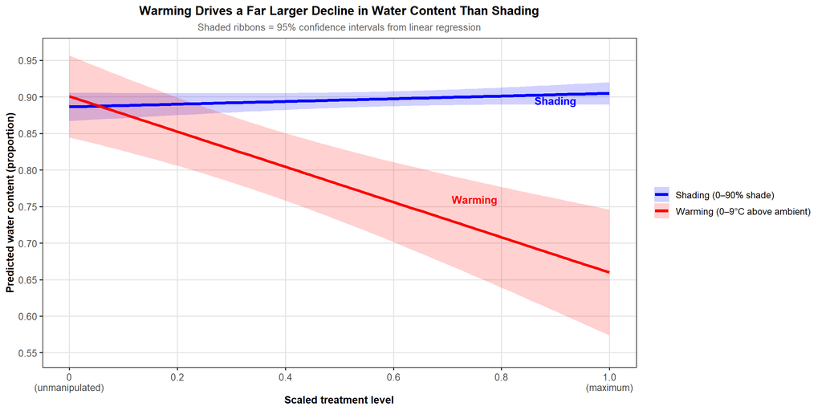

```r
cap3 <- "FIGURE 3: Predicted *Sphagnum* water content (proportion) across the full shading gradient (blue) and warming gradient (orange), derived from separate linear regressions. Both x-axes are scaled so 0 = unmanipulated reference and 1 = maximum treatment level. Ribbons show 95% confidence intervals."

shade_pred <- data.frame(Shade_pct = seq(0, 90, 1))
shade_pred <- cbind(shade_pred,
  predict(lm_shade, newdata = shade_pred, interval = "confidence")) %>%
  rename(fit_WC = fit) %>%
  mutate(driver = "Shading (0–90% shade)", x_scaled = Shade_pct / 90)

warm_pred <- data.frame(Temperature_treatment = seq(0, 9, 0.1))
warm_pred <- cbind(warm_pred,
  predict(lm_warm, newdata = warm_pred, interval = "confidence")) %>%
  rename(fit_WC = fit) %>%
  mutate(driver = "Warming (0–9°C above ambient)", x_scaled = Temperature_treatment / 9)

bind_rows(shade_pred, warm_pred) %>%
  ggplot(aes(x = x_scaled, y = fit_WC, color = driver, fill = driver)) +
  geom_ribbon(aes(ymin = lwr, ymax = upr), alpha = 0.18, color = NA) +
  geom_line(linewidth = 1.5) +
  annotate("text", x = 0.90, y = 0.895,
           label = "Shading", color = "blue",
           fontface = "bold", size = 4) +
  annotate("text", x = 0.75, y = 0.76,
           label = "Warming", color = "red",
           fontface = "bold", size = 4) +
  scale_color_manual(values = c("Shading (0–90% shade)"         = "blue",
                                "Warming (0–9°C above ambient)" = "red"),
                     name = NULL) +
  scale_fill_manual(values  = c("Shading (0–90% shade)"         = "blue",
                                "Warming (0–9°C above ambient)" = "red"),
                    name = NULL) +
  scale_x_continuous(breaks = seq(0, 1, 0.2),
                     labels = c("0\n(unmanipulated)", "0.2", "0.4",
                                "0.6", "0.8", "1.0\n(maximum)")) +
  scale_y_continuous(limits = c(0.55, 0.96), breaks = seq(0.55, 0.95, 0.05)) +
  labs(title = "Warming Drives a Far Larger Decline in Water Content Than Shading",
       subtitle = "Shaded ribbons = 95% confidence intervals from linear regression",
       x = "Scaled treatment level",
       y = "Predicted water content (proportion)") +
  theme_bw(base_size = 12) +
  theme(
    legend.position      = "right",
    plot.title           = element_text(face = "bold", size = 13, hjust = 0.5),
    plot.subtitle        = element_text(size = 10, hjust = 0.5, color = "grey40"),
    axis.title           = element_text(face = "bold", size = 11),
    axis.text            = element_text(size = 10),
    panel.grid.minor     = element_blank(),
    panel.grid.major     = element_line(color = "grey90"),
    plot.caption         = element_text(size = 9, color = "grey50")
  )
```

```r
e <- cn_water %>%
  group_by(CO2_treatment) %>%
  summarise(`Mean WC (proportion)` = round(mean(Water_content, na.rm = TRUE), 3),
            `SE`                   = round(calcSE(Water_content), 4)) %>%
  rename(`CO2 treatment` = CO2_treatment)

knitr::kable(a,
  table.attr = "style='width:35%;'") %>%
  kable_styling(full_width = FALSE, position = "center")
```

| Shade (%) | Mean WC (proportion) | SE |
| --- | --- | --- |
| 0 | 0.893 | 0.0104 |
| 30 | 0.883 | 0.0149 |
| 60 | 0.900 | 0.0119 |
| 80 | 0.898 | 0.0129 |
| 90 | 0.910 | 0.0061 |

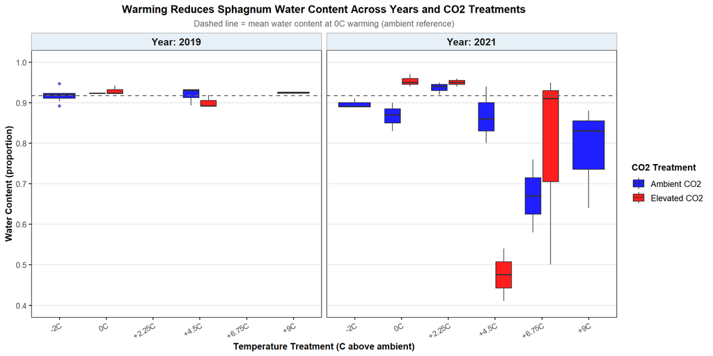

FIGURE 4: Sphagnum water content (proportion) by temperature treatment, CO2 treatment, and year in the SPRUCE phytobiome experiment. Boxes show the interquartile range; whiskers extend to 1.5x IQR. The dashed line marks the mean water content at 0C warming.

```r
cap4 <- "FIGURE 4: Sphagnum water content (proportion) by temperature treatment, CO2 treatment, and year in the SPRUCE phytobiome experiment. Boxes show the interquartile range; whiskers extend to 1.5x IQR. The dashed line marks the mean water content at 0C warming."

cn_water %>%
  ggplot(aes(x = factor(Temperature_treatment), y = Water_content,
             fill = CO2_treatment)) +
  geom_boxplot(outlier.shape = 21, outlier.size = 1.5,
               outlier.alpha = 0.6, alpha = 0.88, linewidth = 0.4) +
  geom_hline(yintercept = mean(cn_water$Water_content[cn_water$Temperature_treatment == 0],
                               na.rm = TRUE),
             lty = "dashed", color = "grey40", linewidth = 0.7) +
  facet_wrap(~ Year, labeller = labeller(Year = c(
    "2019" = "Year: 2019",
    "2020" = "Year: 2020",
    "2021" = "Year: 2021"))) +
  scale_fill_manual(values = c("Ambient" = "blue", "Elevated" = "red"),
                    name = "CO2 Treatment",
                    labels = c("Ambient CO2", "Elevated CO2")) +
  scale_x_discrete(labels = c("-2" = "-2C", "0" = "0C", "2.25" = "+2.25C",
                               "4.5" = "+4.5C", "6.75" = "+6.75C", "9" = "+9C")) +
  scale_y_continuous(limits = c(0.4, 1.0), breaks = seq(0.4, 1.0, 0.1)) +
  labs(title = "Warming Reduces Sphagnum Water Content Across Years and CO2 Treatments",
       subtitle = "Dashed line = mean water content at 0C warming (ambient reference)",
       x = "Temperature Treatment (C above ambient)",
       y = "Water Content (proportion)") +
  theme_bw(base_size = 12) +
  theme(
    legend.position    = "right",
    legend.title       = element_text(face = "bold", size = 11),
    legend.text        = element_text(size = 10),
    strip.background   = element_rect(fill = "#e8f0f7", color = "grey70"),
    strip.text         = element_text(face = "bold", size = 12),
    plot.title         = element_text(face = "bold", size = 13, hjust = 0.5),
    plot.subtitle      = element_text(size = 10, hjust = 0.5, color = "grey40"),
    axis.text.x        = element_text(size = 9, angle = 30, hjust = 1),
    axis.title         = element_text(face = "bold", size = 11),
    panel.grid.minor   = element_blank(),
    panel.grid.major.x = element_blank()
  )
```

```r
summary(lm_two)
```

```
##
## Call:
## lm(formula = Water_content ~ Temperature_treatment + CO2_treatment,
##     data = cn_water)
##
## Residuals:
##      Min       1Q   Median       3Q      Max
## -0.51489 -0.07284 -0.00633  0.11517  0.28111
##
## Coefficients:
##                        Estimate Std. Error t value Pr(>|t|)
## (Intercept)            0.928349   0.030125  30.816  < 2e-16 ***
## Temperature_treatment -0.024003   0.005852  -4.102 0.000145 ***
## CO2_treatmentElevated -0.097438   0.046622  -2.090 0.041530 *
## ---
## Signif. codes:  0 '***' 0.001 '**' 0.01 '*' 0.05 '.' 0.1 ' ' 1
##
## Residual standard error: 0.1621 on 52 degrees of freedom
## Multiple R-squared:  0.3367, Adjusted R-squared:  0.3112
## F-statistic:  13.2 on 2 and 52 DF,  p-value: 2.316e-05
```

```r
aov_two
```

```
## Analysis of Variance Table
##
## Response: Water_content
##                       Df  Sum Sq Mean Sq F value    Pr(>F)
## Temperature_treatment  1 0.57842 0.57842 22.0261 1.995e-05 ***
## CO2_treatment          1 0.11470 0.11470  4.3679   0.04153 *
## Residuals             52 1.36555 0.02626
## ---
## Signif. codes:  0 '***' 0.001 '**' 0.01 '*' 0.05 '.' 0.1 ' ' 1
```

## IV. Discussion

The results of this study show a clear asymmetry between the two drivers of Sphagnum water content examined here. Warming produced a large, statistically significant decline in water content across the +0 to +9°C gradient (0.241 proportion units), while shading produced only a small, non-significant positive trend across the 0–90% shade gradient (0.019 proportion units). These findings indicate that direct thermal effects are the dominant driver of Sphagnum water loss, and that canopy shading alone is unlikely to provide meaningful compensation for warming-driven desiccation. Given that Sphagnum water content controls anaerobic peat conditions and therefore carbon storage, these results have important implications for predicting peatland function under future climate change.

The positive but non-significant response of water content to shading (H1 not supported statistically) is consistent in direction with work by Chong et al. (2012), who demonstrated that shrub shading in peatlands reduces surface evaporation and maintains higher moss moisture. The mechanism likely involves reduced solar energy input at the capitulum surface under dense shade, lowering the vapor pressure gradient that drives evaporative water loss (Goetz & Price, 2015). However, the effect was both small and non-significant in this dataset, as shading shifted water content by only 0.019 proportion units across the entire 0–90% range, and this was not statistically distinguishable from zero (p = 0.1891). The low explanatory power (R² = 0.031) and high within-treatment variability suggest this single-season experiment was underpowered to detect a subtle shading effect, and the relationship may require a multi-year design to resolve. Van de Koot et al. (2024) similarly found that water-holding capacity in Sphagnum depends on both plant and colony structure, and that changes in colony architecture under altered light environments can modify water retention independent of surface evaporation alone, adding complexity that a simple shade gradient may not capture.

In summary, this study provides evidence that temperature is the dominant driver of Sphagnum water content loss in northern peatlands, with shading providing a secondary and smaller buffering effect. These results reinforce projections that northern peatlands face increasing desiccation risk under climate change and suggest that shrub management strategies alone will be insufficient to prevent Sphagnum water stress at the warming levels projected for the boreal zone. Protecting the carbon stored in these ecosystems will ultimately require reducing greenhouse gas emissions rather than relying on vegetation management alone.

## V. Literature Cited

Bengtsson, F., Granath, G., Cronberg, N., & Rydin, H. (2020). Mechanisms behind species-specific water economy responses to water level drawdown in peat mosses. *Annals of Botany*, 126(2), 219–230. https://doi.org/10.1093/aob/mcaa033

Chong, M., Humphreys, E., & Moore, T. R. (2012). Microclimatic response to increasing shrub cover and its effect on Sphagnum CO₂ exchange in a bog. *Écoscience*, 19(1), 89–97. https://doi.org/10.2980/19-1-3489

Dise, N. B. (2009). Peatland response to global change. *Science*, 326(5954), 810–811. https://doi.org/10.1126/science.1174268

Goetz, J. D., & Price, J. S. (2015). Role of morphological structure and layering of Sphagnum and Tomenthypnum mosses on moss productivity and evaporation rates. *Canadian Journal of Soil Science*, 95(2), 109–124. https://doi.org/10.1139/CJSS-2014-092

Gorham, E. (1991). Northern peatlands: Role in the carbon cycle and probable responses to climatic warming. *Ecological Applications*, 1(2), 182–195. https://doi.org/10.2307/1941811

Hanson, P. J., Riggs, J. S., Nettles, W. R., Phillips, J. R., Krassovski, M. B., Hook, L. A., Gu, L., Richardson, A. D., Aubrecht, D. M., Ricciuto, D. M., Warren, J. M., & Barbier, C. (2017). Attaining whole-ecosystem warming using air and deep-soil heating methods with an elevated CO₂ atmosphere. *Biogeosciences*, 14, 861–883. https://doi.org/10.5194/bg-14-861-2017

Keane, B., Shuttleworth, E. L., Evans, M. G., Ritson, J. P., Harris, A., Johnston, A., Alderson, D. M., & Clay, G. D. (2025). Recovery of Sphagnum from drought is controlled by species-specific moisture thresholds. *Scientific Reports*, 15(1), Article 22167. https://doi.org/10.1038/s41598-025-05348-8

Murray, K. J., Tenhunen, J. D., & Nowak, R. S. (1993). Photoinhibition as a control on photosynthesis and production of Sphagnum mosses. *Oecologia*, 96(2), 200–207. https://doi.org/10.1007/BF00317733

Newman, T. R., Wright, N., Wright, B., & Sjögersten, S. (2018). Interacting effects of elevated atmospheric CO₂ and hydrology on the growth and carbon sequestration of Sphagnum moss. *Wetlands Ecology and Management*, 26(5), 763–774. https://doi.org/10.1007/s11273-018-9607-x

Norby, R. J., Baxter, T., Živković, T., & Weston, D. J. (2023). Shading contributes to Sphagnum decline in response to warming. *Ecology and Evolution*, 13(9), e10542. https://doi.org/10.1002/ece3.10542

Petro, C., Carrell, A., Wilson, R. M., Duchesneau, K., Noble-Kuchera, S., Song, T., Iversen, C. M., Childs, J., Schwaner, G., Chanton, J., Norby, R. J., Hanson, P. J., Glass, J. B., Weston, D., & Kostka, J. E. (2023). Climate drivers alter nitrogen availability in surface peat and decouple N₂ fixation from CH₄ oxidation in the Sphagnum moss microbiome. *Global Change Biology*, 29, 3440–3455. https://doi.org/10.1111/gcb.16681

Rydin, H., & Jeglum, J. K. (2013). *The Biology of Peatlands* (2nd ed.). Oxford University Press. https://doi.org/10.1093/acprof:osobl/9780199602995.001.0001

Schultheis, E. H., Hopfensperger, K. N., & Brenner, J. C. (2010). Potential impacts of climate change on Sphagnum bogs of the Southern Appalachian Mountains. *Natural Areas Journal*, 30(4), 417–424. https://doi.org/10.3375/043.030.0407

Van de Koot, W. Q. M., Msonda, J., Olver, O. P., Doonan, J. H., & Nibau, C. (2024). Variation in water-holding capacity in Sphagnum species depends on both plant and colony structure. *Plants*, 13(8), 1061. https://doi.org/10.3390/plants13081061

Yu, Z., Loisel, J., Brosseau, D. P., Beilman, D. W., & Hunt, S. J. (2010). Global peatland dynamics since the Last Glacial Maximum. *Geophysical Research Letters*, 37(13). https://doi.org/10.1029/2010GL043584